# IE6600: Computation and Data Visualisation

Hackathon

Team - 4: Mradul, Parth, Jignasu

[figure not shown]

# Introduction

FIFA is one of the most popular football simulation video games of all times. We are sure that not only us but most of the people (I guess the majority would be males) probably played this game once in their life. Especially if you are a football fan, then you played this game not only once. We, as a football fan, have played FIFA’s series for a long period of time, especially during our school years, and never got bored.

This series is all about football! Football is a big part of our life whether we like it or not. However, some of us like us really like it! :) Because of its importance, football fans also play football video games in order to maintain and live its excitement over and over again. EA’s FIFA football simulation video games have a very long history in game industry and their FIFA series have been playing from many users. Recently, while we were doing research about finding a good dataset, we found FIFA 19 players dataset on Kaggle and got very excited about it. Because we love football and our interests in data space, we wanted to do our own analysis in this dataset.

We discovered an internet database that has all these characteristics for the most recent FIFA game, FIFA 19, as well as actual facts like player salary, value, club, and jersey number. By comprehending the connection between various in-game traits and actual values, we seek to address the problem statement that has been put out. How, for instance, does a player’s overall affect their jersey number? The dreaded number 10 has always drawn our attention, but is it really the shirt that the top players wear? Which quality has helped people earn the most money?

In order to determine the statistical significance of these various in-game and real-world numbers, we are currently proposing to perform a linear regression between them. If a relationship is substantial, we can compare the coefficients and correlation coefficients to comprehend the strength of the association and how this game might be used to forecast or explain real-world values.

Real soccer players and soccer fans are the major focus of our analyses. The most from our analyses will be real soccer players. If we played soccer, we would try to figure out which quality of mine I can develop the most in order to not only become a better player, but also earn more money. By letting players know which qualities are actually valued in soccer and for a club, our analysis should be able to steer their training. Soccer fanatics will also benefit from our analysis as it will help them better understand which characteristics they may want to look for when looking at potential trade prospects for their respective team.

# Data Preprocessing

We gathered our dataset from kaggle’s competitive dataset.The original dataset had 38 varaible column and 17770 including all the attributes for all the players and general real-world information about them such as wage and value.There isn’t explicit information on when this data was collected, however, we do know it was fairly recently since FIFA 19. It is also worth noting that all those statistics are suggested mostly by a 6,000 group of volunteers led by Head of Data Collection & Licensing.

# Section 1

### Which league has most market value captured ?

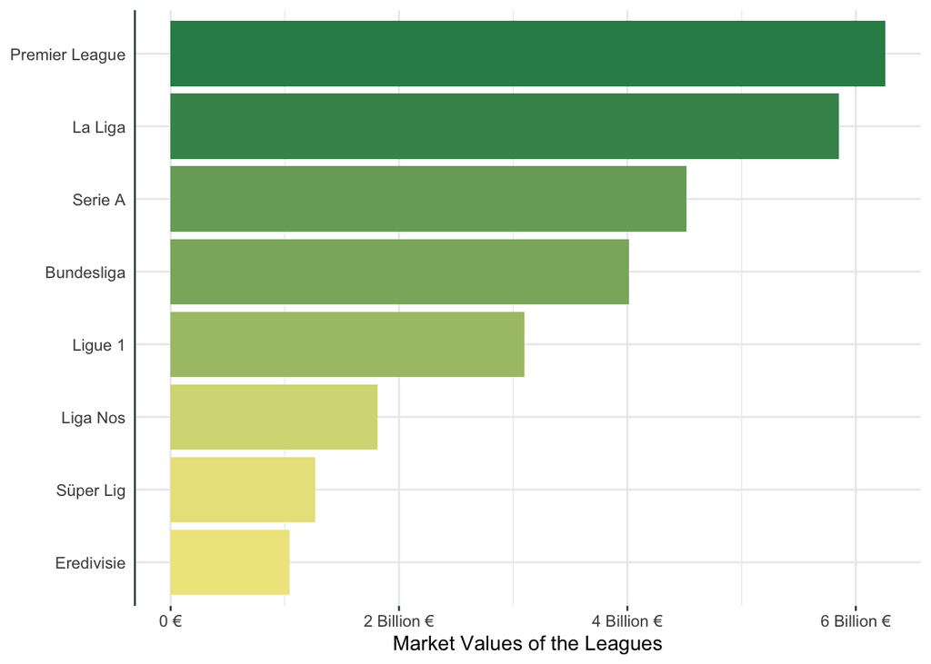

### Across the globe which country has highest number of players participating in the top 5 league played accross the world ?

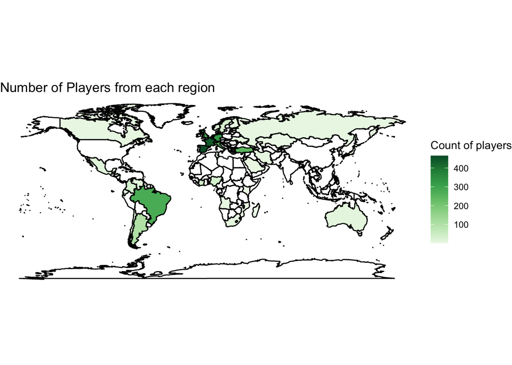

### Players with highest overall rating representing their nation in international leagues

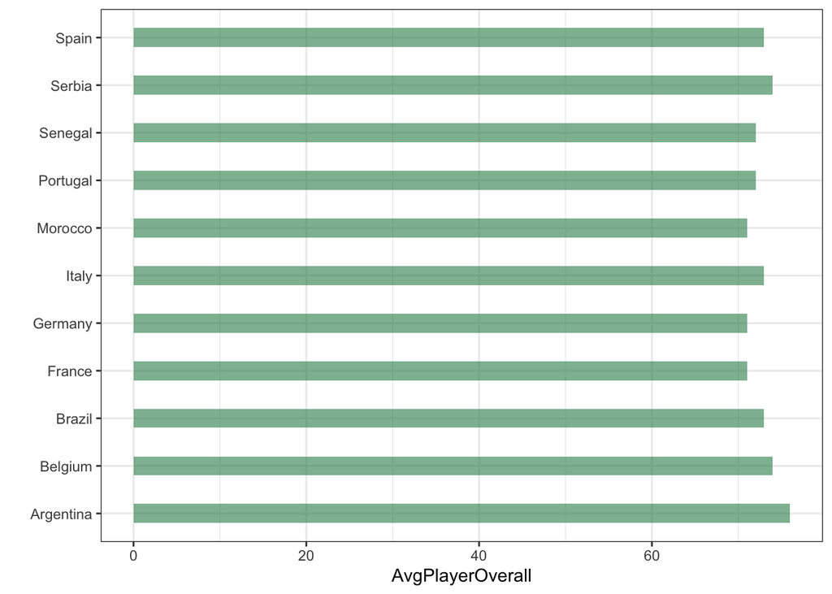

# Section 2

### How age and pace are co-related for any football player ?

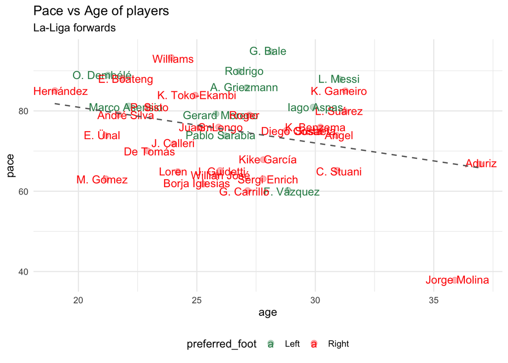

Pace is one of the most important factors for each football players. The requirements of a modern football players are such that speed is required from all the players. Regardless of their position and the role in the team. When it comes to younger football players, this segment of their development is crucial. As we can cleary observe from the above chart regardless of foot, As with the age and injuries, the speed and pace level is gradually decreased. The pace of movement is closely related to football intelligence. Modern football requires players with speed, who can play all the positions in the team.

### How potential and overall rating are affected over the age ?

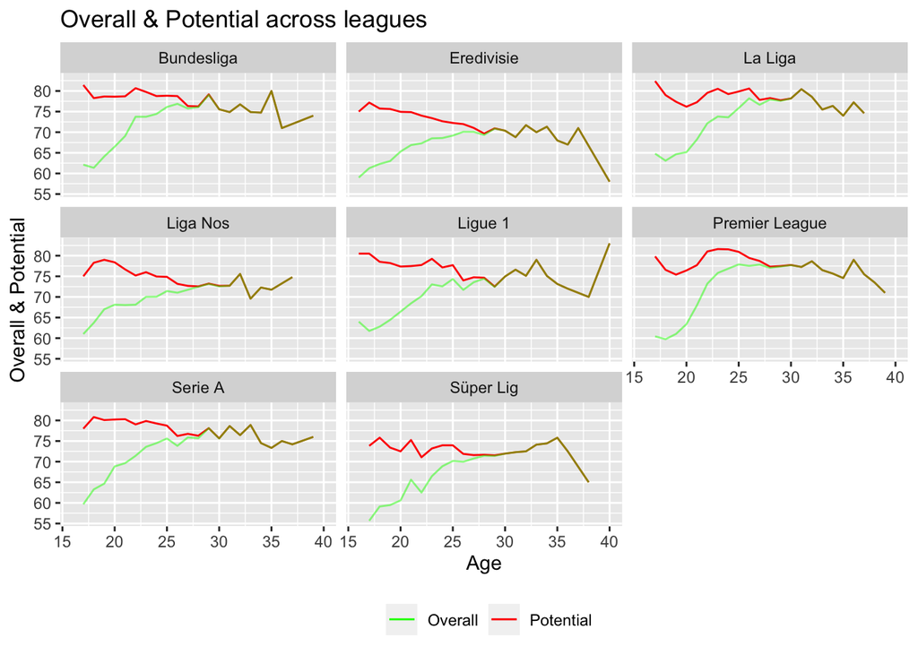

Irrespective of the league, Potential and Overall are the key factors if you are looking for the performance, especially in the FIFA 19 Career Mode. If you’re playing FIFA 19 for the long haul, you’ll eventually need to replace the players in your team once they hit retirement age. The best replacements are of course young players, with ages 17-21 being the sweet spot. Problem is, it can be tricky to judge which FIFA 19 young players are worth your time, as some of the key stats are either hidden in menus, or displayed as aggregate values. Kylian Mbappé is the best young player in FIFA 19, and at only 19 years old, he’s got a ton of room for improvement with a guaranteed high potential rating. Brazilian-born superstar Malcom has seen a huge improvement this year, so we’re predicting big things for the coming season and have high hopes that he will grow significantly over the years thanks to high potential.

Two of the most important attributes a striker needs are speed and quickness. Speed allows a player to outrun a defender and win a 50/50 ball. Quickness provides a striker with a first step that enables them to get past a center-back. Working on footwork and quickness in training can enable a striker to gain the edge they need to be a top player.Holding off defenders is just part of a modern striker’s job. A good No. 9 needs to have the physical strength to keep a defender at bay. This means having both upper and lower body strength. Throughout a 90 minute match, strikers jockey for position with center-backs. A weak forward will simply be tossed aside by a bigger, stronger defender. Having the power to hold off a center-back and wear them down physically is important today.Strikers need to be long on confidence and short on memory. A No. 9 must believe they will score every time they shoot. Players have to take the pitch with the mindset that the team is counting on them. Once a striker losses confidence in themselves, it takes a long time to rediscover form.

# Section 3

### Distribution and average age of the players in each league

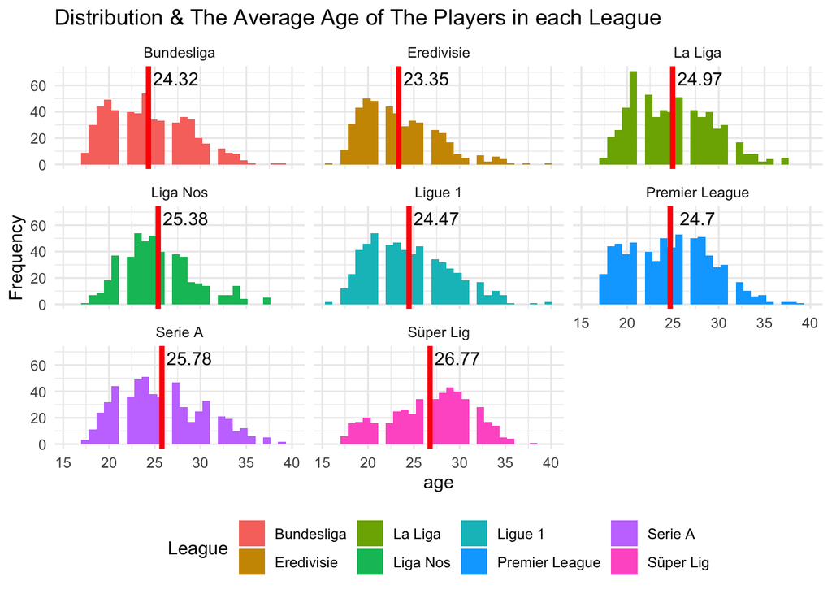

Though they start from unpopular league such as “Eredivisie”, when the players reaches in their prime age i.e 24 or 25, they prefer to play in top league such as Premier league & la liga and as the time passes by they again prefer to play in unpopular leagues such as “Super Lig” as they get closer to 30. So basically they follows the sinosudial curve.

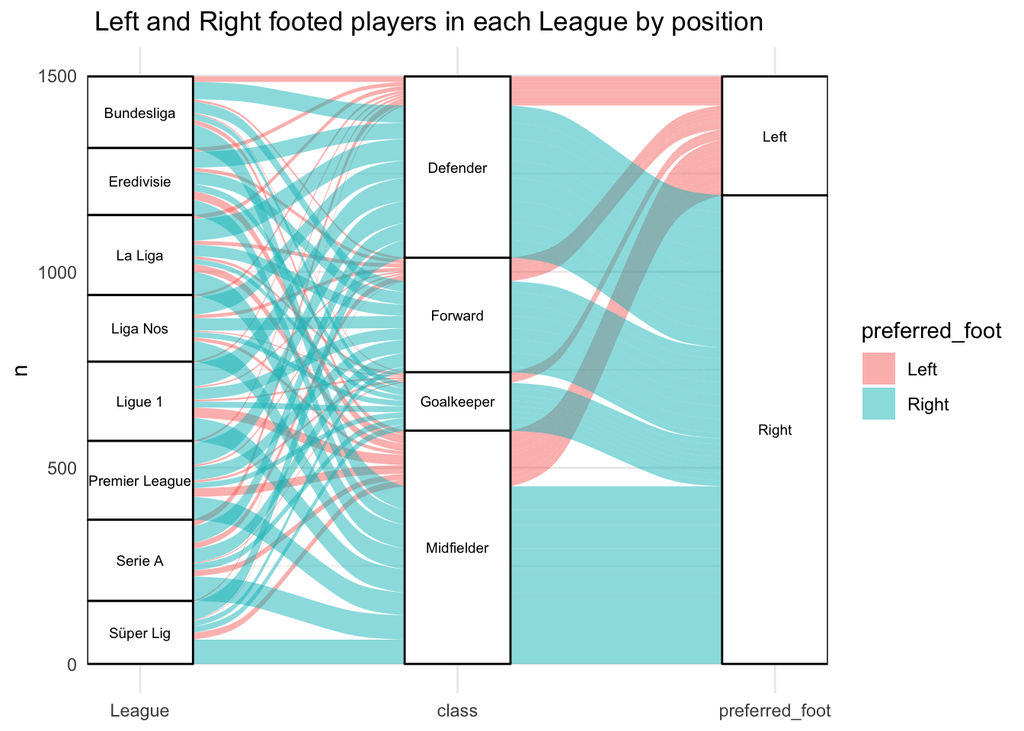

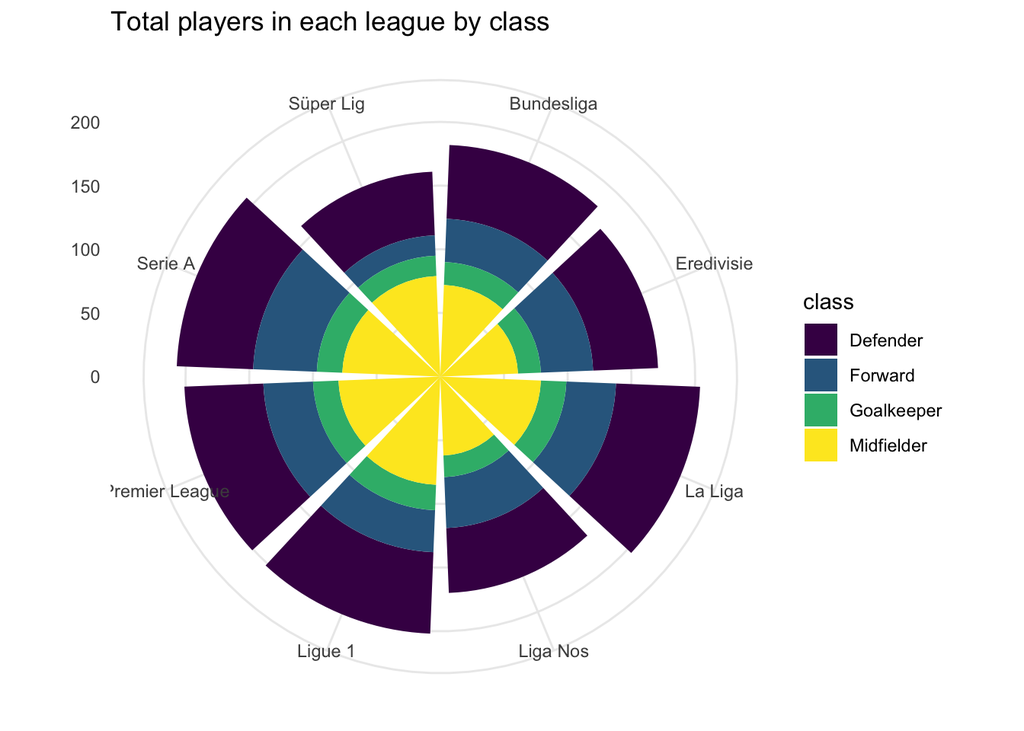

# Summary

In FIFA, each player is rated on various attributes which include stats such as: Pace, Dribbling, Shooting. These attributes combined give each player an overall score. We wanted to figure out, utilizing the current data set, what we could understand about soccer and soccer players in the real world using attributes given to players in the game.

Another interesting insight our group gained in this analysis was when looking at the top young players in the world of professional soccer. Some of the most prominent players in the game today started at an incredibly young age. Messi is a great example of this as he moved with his family to Barcelona at the age of 13 to fulfill his dream and potential.

Despite our visualizations indicating interesting trends and analysis, we believe there are a few limitations which future analysts could explore further. One of the largest limitations of our analysis was the data itself. Most of the findings do not tell us much about the players in real life but rather are reflective of the methodology employed by EA Sports to assign attributes to players in this game.

Some of the analysis done, however, will hold concrete in the world when the information used is not subjective. These variables include information like wage, club, position, jersey number, nationality, age, etc. Some of the analysis did give us insight into how the subjective attributes are correlated to the objective attributes about the players.

Another limitation to our analysis was our specific approach to answer a broad goal. The question we started with was incredibly broad and we answered smaller, more specific questions throughout the process. We believe, however, that a different set of these subset questions could have navigated our analysis to a different direction. For example, we could have looked more into the positional groupings. Soccer players have various skills. For each position, different sets of skills are needed. For example, the most important skills required for a defender are completely different from the ones required by attacker/striker or other positions. A detailed analysis using Linear regression modeling could have been applied to identify or highlight the most important set of skills or key attributes for a particular player’s position. This gap was a limitation to our analysis. We encourage other groups to try such an analysis in the future as it could possibly indicate the similarity between Main stats and Face stats. This analysis might help us further understand how EA calculates face stats and what weight is provided to the individual attributes in each cumulative face stat metric. Either way, it feels intuitive enough that a Principal component analysis (PCA) could show that players can be categorized into groups, such as ‘attacking, technical’, ‘fast, dribbling’, ‘attacking, physical’.

We hope our analysis can be evaluated further and built upon in the future to reveal more insights about the fifa soccer world.

# References

1.https://www.data-to-viz.com

2.https://bookdown.org/yihui/rmarkdown/html-document.html

3.https://www.r-graph-gallery.com/

4.https://sportzpoint.com/football/10-most-valuable-football-leagues-in-the-world/